# Lab08: Mais Inferência para dados numéricos

# Introdução

```r
library(ggplot2)
#library(plyr)
library(tidyr)
library(dplyr)
library(DescTools)
library(htmltools)
library(knitr)
library(rmarkdown)
library(combinat)
library(kableExtra) #Para gerar tabelas com um layout agradável
```

Este relatório trata da atividade denominada *Mais inferência para dados numéricos*. Resolvi fazer essas atividades para poder ter uma fluência básica em R, especialmente no tocante às funções dos pacotes básicos de estatística e de carregamento de bases de dados externas. Antes de fazer esse “minicurso”, eu já tinha feito um curso introdutório na Udemy, no qual aprendi os comandos básicos, carregamento de pacotes, tipos de dados, etc[^1].

## Conteúdos abordados neste laboratório

- Intervalo de confiança
- Teste t para a diferença entre duas médias
- Teste F para a igualdade entre as variâncias de duas populações normais
- ANOVA
- Correção de Bonferroni

# Salários Americanos

Neste laboratório, nós iremos trabalhar com uma amostra aleatória de 2000 observações do ACS (American Community Survey, ou Pesquisa da Comunidade Americana) 2012. Este conjunto de dados contém informações sobre a força de trabalho e os salários americanos. Você deve carregar esse banco de dados à partir do comando abaixo[^2].

```r
load("acs12.RData")
```

Temos dados de 13 variáveis diferentes, algumas qualitativas e outras quantitativas. Cada variável representa uma das seguintes informações:

| Variable | Description |
| --- | --- |
| `income` | Annual income |
| `employment` | Employment status |
| `hrs_work` | Hours worked per week |
| `race` | Race |
| `age` | Age, in years |
| `gender` | Gender |
| `citizen` | Whether the person is a U.S. citizen |
| `time_to_work` | Travel time to work, in minutes |
| `lang` | Language spoken at home |
| `married` | Whether the person is married |
| `edu` | Education level |
| `disability` | Whether the person is disabled |
| `birth_qrtr` | The quarter of the year that the person was born, e.g. Jan thru Mar |

Note que este conjunto de dados contém algumas pessoas que não estão na força de trabalho ou estão desempregadas, como podemos ver por meio dos comandos abaixo:

```r
glimpse(acs12$employment)
```

```
##  Factor w/ 3 levels "not in labor force",..: 1 1 NA 1 1 3 NA NA NA 3 ...
```

```r
levels(acs12$employment)
```

```
## [1] "not in labor force" "unemployed"         "employed"
```

```r
acs12 %>%
  select(employment) %>%
  group_by(employment) %>%
  summarise(
    n = n(),
    percent = scales::percent(n()/nrow(acs12), accuracy = NULL)
    ) %>%
  kable() %>%
   kable_styling(
     full_width = F,
     bootstrap_options = c("striped", "hover", "condensed", "responsive")
     )
```

| employment | n | percent |
| --- | --- | --- |
| not in labor force | 656 | 33% |
| unemployed | 106 | 5% |
| employed | 843 | 42% |
| NA | 395 | 20% |

Primeiramente, vamos filtrar os entrevistados que estão empregados. Vamos chamar este banco de dados como `acs_emp`.

```r
acs_emp = acs12 %>%
  filter(employment == "employed")
```

Podemos ver assim que o percentual de empredados na nossa amostra é de 42%.

Agora, vamos dar um olhada na distribuição da renda de acordo com o gênero. O primeiro passo é criar uma visualização:

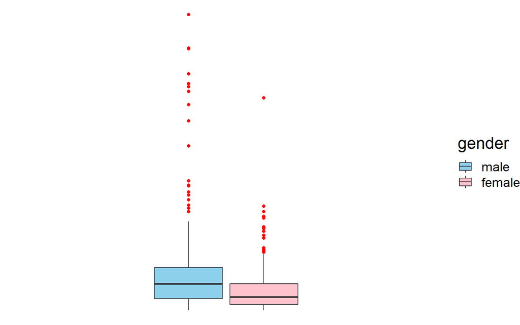

```r
acs_emp %>%
  ggplot(aes(y = income, x = "", fill = gender)) +
  geom_boxplot(
    outlier.colour = "red",
    width = 0.4,
    alpha = 0.95
  ) +
  theme_void() +
  theme(text = element_text(size = 18)) +
  scale_fill_manual(values = c("skyblue", "pink"))
```

Como podemos ver nos boxplots, os homens parecem ganhar mais que as mulheres.

Podemos também obter algumas estatísticas descritivas como a média, desvio padrão e tamanho das amostras.

```r
acs_emp %>%
  group_by(gender) %>%
  summarise(
    media = mean(income),
    dp = sd(income),
    n = n()
  ) %>%
   kable() %>%
   kable_styling(
     full_width = F,
     bootstrap_options = c("striped", "hover", "condensed", "responsive")
     )
```

| gender | media | dp | n |
| --- | --- | --- | --- |
| male | 55887.23 | 68767.88 | 470 |
| female | 29243.70 | 32025.98 | 373 |

Assim, à primeira vista, os homens parecem ganhar muito mais que as mulheres, em média.

> Construa um intervalo de confiança de 95% para a diferença entre os rendimentos médios dos homens e mulheres e interprete este intervalo.

Supondo a normalidade dos dados nas respectivas populações, podemos escrever um intervalo de confiança de 95% para a diferença entre as rendas médias de homens e mulheres, por meio da distribuição t de Student:

```r
# Renda dos homens
income_male = acs_emp %>%
  filter(gender == "male") %>%
  select(income) %>%
  drop_na()

xbar1 = mean(income_male$income)
std1 = sd(income_male$income)
n1 = nrow(income_male)

# Renda das mulheres
income_female = acs_emp %>%
  filter(gender == "female") %>%
  select(income) %>%
  drop_na()

xbar2 = mean(income_female$income)
std2 = sd(income_female$income)
n2 = nrow(income_female)

# Testando a igualdade das variâncias
var.test(income_male$income, income_female$income)
```

```
##
##  F test to compare two variances
##
## data:  income_male$income and income_female$income
## F = 4.6107, num df = 469, denom df = 372, p-value < 2.2e-16
## alternative hypothesis: true ratio of variances is not equal to 1
## 95 percent confidence interval:
##  3.798410 5.584551
## sample estimates:
## ratio of variances
##           4.610694
```

```r
# Portanto, como o teste F para igualdade das variâncias indicou que as variâncias dos dois gêneros são diferentes, o número de graus de liberdade para o teste t será dado por:
A = std1^2/n1
B = std2^2/n2

dof = ((A+B)^2)/(A^2/(n1-1) + B^2/(n2-1)) #Graus de liberdade
std_err = sqrt(std1^2/n1 + std2^2/n2) #Erro padrão do estimador
q = qt(0.975, df = dof) #Quantil que define o IC de 95%

IC = xbar1 - xbar2 + c(-1,1)*q*std_err

cat(
  "Intervalo de confiança para a diferença entre as médias:\n",
  IC
  )
```

```
## Intervalo de confiança para a diferença entre as médias:
##  19615.96 33671.11
```

Como o intervalo de confiança para a diferença entre as rendas médias dos homens e das mulheres não contêm o zero, concluímos que as duas médias são diferentes. Além disso, o sinal da diferença também indica que a renda média dos homens é de fato maior que a das mulheres.

> Qual é o nível de significância para o teste de hipóteses equivalente ao intervalo de confiança construído que avalia se existe uma diferença significativa entre os rendimentos médios de homens e mulheres?

Como sabemos, um intervalo de confiança de $100 \cdot \gamma \%$ equivale a um nível se significância $\alpha = 1 - \gamma$, Assim, se estamos escrevendo um intervalo de confiança de 95%, isso equivale a um teste de hipóteses com nível de significância $\alpha = 0.05$.

> Realize este teste de hipóteses e interprete seus resultados no contexto dos dados e da questão de pesquisa. Seus resultados do intervalo de confiança e do teste de hipóteses concordam?

Podemos fazer um teste t para a diferença entre a renda média de homens e mulheres, supondo populações normais:

```r
# Como sabemos que as variâcias dos dois grupos são muito diferentes, podemos supor diretamente que essas diferenças também ocorrem nas populações.

# Fazendo o teste t não pareado para a diferença entre as duas médias
t.test(
  income_male$income,
  income_female$income,
  paired = F,
  alternative = "two.sided"
  )
```

```
##
##  Welch Two Sample t-test
##
## data:  income_male$income and income_female$income
## t = 7.4437, df = 694.94, p-value = 2.903e-13
## alternative hypothesis: true difference in means is not equal to 0
## 95 percent confidence interval:
##  19615.96 33671.11
## sample estimates:
## mean of x mean of y
##  55887.23  29243.70
```

Como $p \approx 0$, rejeitamos a hipótese de iguldade das duas médias para qualquer um dos intervalos de significância comumente adotados, o que está em perfeito acordo com o intervalo de confiança já escrito no item anterior. Além disso, a função `t.test()` também retorna o intervalo de confiança de 95% para a diferença entre as médias, e o resultado é o mesmo já calculado anterioriormente de maneira “manual”.

## Variáveis de confusão

Há uma clara diferença entre os salários médios dos homens e das mulheres, mas poderia alguma, ou a totalidade, desta diferença ser atribuída a alguma outra variável que não seja o gênero? Nós chamamos tais variáveis como **variáveis de confusão**. Vamos avaliar se a variável `hrs_work` confunde a relação entre gênero e renda. Mas antes de fazermos isso, vamos primeiro converter a variável `hrs_work` a uma variável qualitativa (com níveis de “integral” e “parcial”) para que possamos usar os métodos que aprendemos até agora na execução da análise.

## Convertendo variáveis

Queremos criar uma nova variável, digamos `emp_type`, com níveis de “integral” ou “partial”, relacionados ao fato do empregado trabalhar 40 horas ou mais por semana ou menos do que 40 horas, respectivamente. Lembre-se que nós podemos adicionar uma nova variável ao conjunto de dados por meio da função `mutate`.

```r
acs_emp = acs_emp %>%
  mutate(
    emp_type = ifelse(hrs_work >= 40, "integral", "partial")
  )
```

A função `ifelse()` tem três argumentos: um teste lógico, retorna valores `TRUE` para os elementos verdadeiros do teste, e valores `FALSE` para elementos falsos do teste. Neste caso, `emp_type` será codificado como “integral” para observações onde `hrs_work` é maior ou igual a 40, e “partial” para o caso contrário.

Para descobrir a proporção de cada caso, nós retornamos às estatísticas descritivas:

```r
acs_emp %>%
  group_by(emp_type) %>%
  summarise(
    time_ratio = scales::percent(n()/nrow(acs_emp))
  ) %>%
  kable() %>%
   kable_styling(
     full_width = F,
     bootstrap_options = c("striped", "hover", "condensed", "responsive")
     )
```

| emp_type | time_ratio |
| --- | --- |
| integral | 71% |
| partial | 29% |

Aqui, primeiramente, nós agrupamos os dados pela nova variável `emp_type`, e então calculamos as proporções de trabalhadores a tempo integral e parcial ao contar quantos elementos existem em cada grupo (com a função `n()`), e em seguida dividimos esse número pelo total de linhas do conjunto de dados.

> Contrua um gráfico de barras da distribuição da variável `emp_type`, e também inclua as estatísticas descritivas que você calculou acima em sua resposta. Qual o percentual da amostra representa os trabalhadores em tempo integral e tempo parcial?

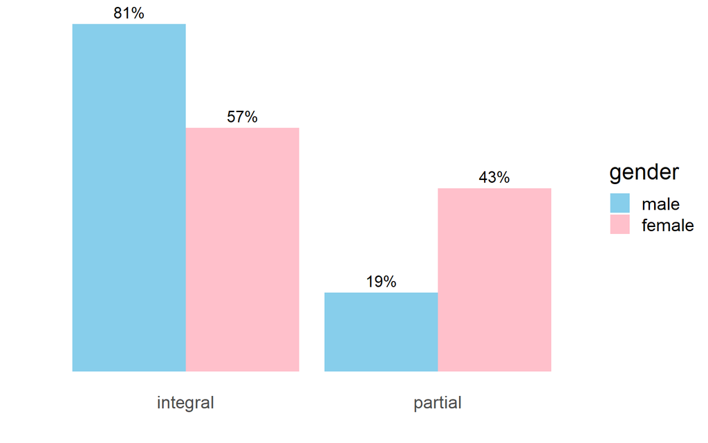

```r
acs_emp %>%
  ggplot(aes(x = emp_type, group = gender)) +
  geom_bar(
    aes(y = after_stat(prop), fill = gender),
    stat = "count",
    position = "dodge"
    ) +
  geom_text(
    aes(label = scales::percent(after_stat(prop)), y = after_stat(prop)),
    stat = "count",
    position = position_dodge(.9),
    vjust = -0.5,
    size = 4.5
    ) +
  # scale_y_continuous(labels = scales::percent) +
  theme_minimal() +
  labs(
    x = "",
    y = ""
  ) +
  theme(
    axis.text.y=element_blank(),
    axis.ticks.y=element_blank()
    ) +
  theme(
    panel.grid.major = element_blank(),
    panel.grid.minor = element_blank()
    ) +
  theme(text = element_text(size = 18)) +
  scale_fill_manual(values = c("skyblue", "pink"))
```

Assim, concluímos que a menor renda das mulheres quando comparada à dos homens PODE ser devido à diferença nos regimes de trabalho, uma vez que, dentre os homens, apenas 19% trbalham em período parcial, ao passo que, dentre as mulheres, esse percentual é de 43%.

# Por sua conta

1. Crie dois subconjuntos do conjunto de dados `acs_emp`: um para trabalhadores a tempo integral e um outro para os trabalhadores a tempo parcial. Nenhuma interpretação é necessária para esta questão, apenas o código é suficiente.

```r
partial = acs_emp %>%
  filter(emp_type == "partial")

integral = acs_emp %>%
  filter(emp_type == "integral")
```

2. Use um teste de hipóteses para avaliar se existe diferença na renda média dos trabalhados masculinos e femininos que trabalham em tempo integral. Se a diferença for significativa, inclua um intervalo de confiança (equivalente ao nível de significância do teste) estimando a magnitude da diferença na renda média.

Podemos fazer um teste t, supondo a normalidade dos dados:

```r
# Renda dos homens
income_male_integral = integral %>%
  filter(gender == "male") %>%
  select(income) %>%
  drop_na()

# Renda das mulheres
income_female_integral = integral %>%
  filter(gender == "female") %>%
  select(income) %>%
  drop_na()

teste_t = t.test(
  income_male_integral$income,
  income_female_integral$income,
  paired = F,
  var.equal = F,
  alternative = "two.sided")

teste_t
```

```
##
##  Welch Two Sample t-test
##
## data:  income_male_integral$income and income_female_integral$income
## t = 5.4822, df = 590.5, p-value = 6.232e-08
## alternative hypothesis: true difference in means is not equal to 0
## 95 percent confidence interval:
##  15037.15 31825.72
## sample estimates:
## mean of x mean of y
##  63183.55  39752.11
```

Como $p << 0.05$, concluímos que, provavelmente, existe diferença nas rendas médias de homens e mulheres que compõem a força de trabalho americana.

```r
cat(
  "Intervalo de confiança de 95% para a diferença nas rendas médias de homens e mulheres que trabalham em tempo integral:\n",
  teste_t$conf.int[1:2])
```

```
## Intervalo de confiança de 95% para a diferença nas rendas médias de homens e mulheres que trabalham em tempo integral:
##  15037.15 31825.72
```

Portanto, vemos que, mesmo entre as pessoas que trabalham em tempo integral, existe uma diferença estatisticamente significativa entre as rendas médias de homens e mulheres.

3. Use um teste de hipóteses para avaliar se existe diferença na renda média dos trabalhados masculinos e femininos que trabalham em tempo parcial. Se a diferença for significativa, inclua um intervalo de confiança (equivalente ao nível de significância do teste) estimando a magnitude da diferença na renda média.

Novamente, podemos fazer um teste t, supondo a normalidade dos dados:

```r
# Renda dos homens
income_male_partial = partial %>%
  filter(gender == "male") %>%
  select(income) %>%
  drop_na()

# Renda das mulheres
income_female_partial = partial %>%
  filter(gender == "female") %>%
  select(income) %>%
  drop_na()

teste_t = t.test(
  income_male_partial$income,
  income_female_partial$income,
  paired = F,
  var.equal = F,
  alternative = "two.sided")

teste_t
```

```
##
##  Welch Two Sample t-test
##
## data:  income_male_partial$income and income_female_partial$income
## t = 1.3249, df = 97.058, p-value = 0.1883
## alternative hypothesis: true difference in means is not equal to 0
## 95 percent confidence interval:
##  -4239.58 21264.16
## sample estimates:
## mean of x mean of y
##  23766.67  15254.38
```

Como $p \approx 0.19 > 0.05$, concluímos que a diferença nas rendas médias de homens e mulheres que trabalham em tempo parcial não é significativa. Portanto, as rendas média são provavelmente iguais para aqueles que trabalham menos que 40 horas semanais.

4. O que os resultados do seu teste de hipóteses sugerem sobre as horas trabalhadas (em tempo integral ou parcial) constituirem ou não uma variável de confusão na relação entre gênero e renda?

Conforme comentado acima, concluímos que a quantidade de horas trabalhadas é de fato uma variável de confusão, uma vez que o resultado do teste de hipóteses muda quando consideramos apenas aqueles que trabalham menos de 40 horas semanais. Quando consideramos os que trabalham 40 horas ou mais, por outro lado, o resultado permanece o mesmo.

5. Que tipo de teste deveríamos utilizar para compararmos os salários médios em torno dos vários grupos de raça/etnia neste conjunto de dados? Explique seu raciocínio.

Primeiro, vamos ver quantos grupos existem para o fator raça no conjunto de dados completo:

```r
levels(acs12$race)
```

```
## [1] "white" "black" "asian" "other"
```

Portanto, vemos que temos 4 grupos dentro do fator raça. Quando queremos comparar as médias de mais que dois grupos, podemos usar um teste ANOVA (*Analysis of Variance*). Esse teste se baseia na variabilidade dentro dos grupos e entre os grupos e utiliza a distribuição F para testar a hipótese de igualdade entre as médias de todos os grupos contra a hipótese alternativa de que a média de pelo menos um grupo é diferente das demais.

6. Realize este teste de hipóteses utilizando a função inference. Note que a variável resposta é a renda e a variável explicativa é raça. Você terá que descobrir os argumentos restantes para a função. Use uma abordagem de tentativa e erro, e deixe que os erros o informe sobre o que mais precisa ser especificado, e como. (Nota: Utilize o conjunto de dados que contém os registros de todos os funcionários participantes: nomeie acs_map) Escreva suas hipóteses, e interprete a sua conclusão no contexto dos dados e da questão de pesquisa. Note que a função inference, por padrão, usa um nível de significância de 0,05 para a ANOVA, serão executados pares de testes t e p-valores serão reportados para eles, se a ANOVA for significativa. (Note também que você pode mudar o nível de significância definindo sig_level igual a algum outro valor.)

Aqui, podemos combinar as funções `aov()` e `anova()` para gerar o resultado do teste.

```r
anova1 = aov(income ~ race, acs12)
result = anova(anova1)
result
```

```
## Analysis of Variance Table
##
## Response: income
##             Df     Sum Sq    Mean Sq F value    Pr(>F)
## race         3 5.4434e+10 1.8145e+10  8.4832 1.363e-05 ***
## Residuals 1619 3.4629e+12 2.1389e+09
## ---
## Signif. codes:  0 '***' 0.001 '**' 0.01 '*' 0.05 '.' 0.1 ' ' 1
```

```r
rsq = result$`Sum Sq`[1]/sum(result$`Sum Sq`)

cat(
  "Coeficiente de explicação do modelo utilizado",
  rsq
)
```

```
## Coeficiente de explicação do modelo utilizado 0.0154761
```

Com o resultado do teste acima, vemos que devemos rejeitar a hipótese nula de igualdade das rendas médias para os 4 diferentes grupos, já que p < 0,05. Porém, devemos também notar que os diferentes grupos só respondem por cerca de 1,5% da variabilidade dos dados como um todo. Sendo assim, a maior parte da variância desse conjunto de dados é devida a outros fatores.

Agora que rejeitamos a hipótese de igualdade das médias, podemos compará-las duas a duas, por meio da construção de intervalos de confiança para cada comparação, utilizando o fator de correção de Bonferroni[^3]. Esse fator corrige o nível de significância para as comparações dois a dois, considerando o nível de significância global. Caso a correção não fosse considerada, o nível de significância global não seria mantido ao fazer as comparações dois a dois, e poderíamos obter diferenças espúrias entre as médias.

O fator de correção de Bonferroni considera que o nível de significância que deve ser usado em cada comparação deve ser igual a $\alpha^*/m$, em que $\alpha^*$ é o nível de significância global do teste e $m$ é o número de comparações a ser feitas. Vamos considerar aqui o número máximo de comparações, que é igual a $C_{4,2}$, já que temos 4 níveis para o fator `race`.

Vamos primeiro listar as possíveis comparações, utilizando para isso a biblioteca `combinat`:

```r
config = combn(levels(acs12$race), 2)
config #configurações possíveis
```

```
##      [,1]    [,2]    [,3]    [,4]    [,5]    [,6]
## [1,] "white" "white" "white" "black" "black" "asian"
## [2,] "black" "asian" "other" "asian" "other" "other"
```

```r
m = ncol(config) #número de comparações possíveis
I = length(levels(acs12$race)) #número de grupos
```

Agora, vamos calcular as estatísticas de cada grupo, para então podermos escrever os IC’s:

```r
grupos = acs12 %>%
  group_by(race) %>%
  summarise(
    n = n(),
    xbar = mean(income, na.rm = T),
    s = sd(income, na.rm = T)
  )
grupos %>%
  kable() %>%
  kable_styling(
    full_width = F,
    bootstrap_options = c("striped", "hover", "condensed",
                          "responsive")
    )
```

| race | n | xbar | s |
| --- | --- | --- | --- |
| white | 1555 | 24047.48 | 46494.58 |
| black | 206 | 14684.94 | 21979.29 |
| asian | 87 | 45487.33 | 86672.18 |
| other | 152 | 16650.93 | 25944.15 |

Agora, vamos calcular o desvio padrão dentro dos grupos $S_e$, o qual pode ser determinado a partir do resultado da ANOVA ($QMDen$) e o erro padrão para cada comparação:

```r
#Tamanho de cada grupo
n1 = grupos$n[1]
n2 = grupos$n[2]
n3 = grupos$n[3]
n4 = grupos$n[4]

#Tamanho do conjunto de dados
n = nrow(acs12)

#Devio padrão dos resíduos
se = sqrt(result$`Mean Sq`[2])

#white-black
ep12 = se*sqrt(1/n1 + 1/n2)
#white-asian
ep13 = se*sqrt(1/n1 + 1/n3)
#white-other
ep14 = se*sqrt(1/n1 + 1/n4)
#black-asian
ep23 = se*sqrt(1/n2 + 1/n3)
#black-other
ep24 = se*sqrt(1/n2 + 1/n4)
#asian-other
ep34 = se*sqrt(1/n3 + 1/n4)

#quantil para o IC de 95%, com fator de correção
qb = qt(1-(1/m)*0.05/2, df = n-I)
```

Finalmente, vamos determinar os IC’s para cada comparação:

```r
cat(
  "IC(mu1 - mu2; 95%) =",
  grupos$xbar[1] - grupos$xbar[2] + c(-1,1)*qb*ep12,
  "\nIC(mu1 - mu3; 95%) =",
  grupos$xbar[1] - grupos$xbar[3] + c(-1,1)*qb*ep13,
  "\nIC(mu1 - mu4; 95%) =",
  grupos$xbar[1] - grupos$xbar[4] + c(-1,1)*qb*ep14,
  "\nIC(mu2 - mu3; 95%) =",
  grupos$xbar[2] - grupos$xbar[3] + c(-1,1)*qb*ep23,
  "\nIC(mu2 - mu4; 95%) =",
  grupos$xbar[2] - grupos$xbar[4] + c(-1,1)*qb*ep24,
  "\nIC(mu3 - mu4; 95%) =",
  grupos$xbar[3] - grupos$xbar[4] + c(-1,1)*qb*ep34
)
```

```
## IC(mu1 - mu2; 95%) = 306.7465 18418.34
## IC(mu1 - mu3; 95%) = -34895.59 -7984.107
## IC(mu1 - mu4; 95%) = -2982.923 17776.04
## IC(mu2 - mu3; 95%) = -46418.99 -15185.8
## IC(mu2 - mu4; 95%) = -15025.65 11093.68
## IC(mu3 - mu4; 95%) = 12416.78 45256.04
```

Poderíamos também fazer todas essas comparações entre pares de médias por meio da função `PostHocTest`, da biblioteca `Desctools`, o que pouparia muito trabalho:

```r
PostHocTest(anova1, method = "bonferroni", conf.level = 0.95)
```

```
##
##   Posthoc multiple comparisons of means : Bonferroni
##     95% family-wise confidence level
##
## $race
##                   diff     lwr.ci      upr.ci    pval
## black-white  -9362.545 -19496.543    771.4525 0.08866 .
## asian-white  21439.849   6924.799  35954.8987 0.00060 ***
## other-white  -7396.558 -19639.271   4846.1541 0.66425
## asian-black  30802.394  13773.235  47831.5540 1.2e-05 ***
## other-black   1965.987 -13173.023  17104.9968 1.00000
## other-asian -28836.407 -47198.825 -10473.9899 0.00021 ***
##
## ---
## Signif. codes:  0 '***' 0.001 '**' 0.01 '*' 0.05 '.' 0.1 ' ' 1
```

7. Escolha outra variável numérica à partir do conjunto de dados para ser a variável resposta, e também escolha uma variável explicativa qualitativa (pode ser uma que usamos antes). Realize o teste de hipóteses apropriado, utilizando a função inference, para comparar as médias da variável resposta entre os diferentes casos da variável explicativa. Certifique-se de indicar a sua questão de pesquisa, e interpretar a sua conclusão no contexto do conjunto de dados. Note que você pode usar o banco de dados correspondente à força de trabalho ativa, `acs_emp`, ou qualquer outro subconjunto que você selecionar.

Para decidir quais variáveis utilizar, vamos ver as possibilidades dentro do conjunto de dados original:

```r
acs_emp %>%
  head() %>%
  kable() %>%
  kable_styling(
    full_width = F,
    bootstrap_options = c("striped", "hover", "condensed",
                          "responsive")
    )
```

| income | employment | hrs_work | race | age | gender | citizen | time_to_work | lang | married | edu | disability | birth_qrtr | emp_type |
| --- | --- | --- | --- | --- | --- | --- | --- | --- | --- | --- | --- | --- | --- |
| 1700 | employed | 40 | other | 35 | female | yes | 15 | other | yes | hs or lower | yes | jul thru sep | integral |
| 45000 | employed | 84 | white | 27 | male | yes | 40 | english | yes | hs or lower | no | oct thru dec | integral |
| 8600 | employed | 23 | white | 69 | female | yes | 5 | english | no | hs or lower | no | jul thru sep | partial |
| 33500 | employed | 55 | white | 52 | male | yes | 20 | english | yes | hs or lower | no | apr thru jun | integral |
| 4000 | employed | 8 | white | 67 | female | yes | 10 | english | yes | hs or lower | no | apr thru jun | partial |
| 19000 | employed | 35 | white | 36 | female | yes | 15 | english | yes | college | no | jul thru sep | partial |

Olhando para o dataframe, percebemos que a única variável que faz sentido usar como variável resposta é a renda (`income`) dos participantes do estudo. Porém, neste caso, vamos utilizar o nível de escolaridade da pessoa como variável explicativa.

Primeiro, vamos ver quantos níveis tem a variável `edu`:

```r
levels(acs_emp$edu)
```

```
## [1] "hs or lower" "college"     "grad"
```

Vemos, portanto, que essa variável possui 3 níveis: “hs or lower”, “college” e “grad”, que se referem a pessoas com escolaridade menor ou igual a ensino médio, cursando faculdade e já graduados, respectivamente.

O problema de pesquisa aqui é testar se a renda média dos entrevistados é a mesma para os 3 níveis analisados. Para verificar, vamos usar ANOVA:

```r
anova2 = aov(income ~ edu, acs_emp)
result = anova(anova2)
result
```

```
## Analysis of Variance Table
##
## Response: income
##            Df     Sum Sq    Mean Sq F value    Pr(>F)
## edu         2 4.1309e+11 2.0654e+11  74.335 < 2.2e-16 ***
## Residuals 840 2.3340e+12 2.7786e+09
## ---
## Signif. codes:  0 '***' 0.001 '**' 0.01 '*' 0.05 '.' 0.1 ' ' 1
```

```r
rsq = result$`Sum Sq`[1]/sum(result$`Sum Sq`)

cat(
  "Coeficiente de explicação do modelo:",
  rsq
)
```

```
## Coeficiente de explicação do modelo: 0.1503731
```

Vemos assim que cerca de 15% da variância dos dados é devido aos diferentes níveis de escolaridade. Além disso, esse resultado é significativo para qualquer nível de significância usualmente utilizado. Dessa forma, concluímos por rejeitar a hipótese nula de que as rendas médias são iguais para os 3 grupos de escolaridade.

Vamos agora testar a igualdade das médias salariais duas a duas. Desta vez, vamos fazer isso diretamente através da função `PostHocTest`:

```r
PostHocTest(anova2, method = "bonferroni", conf.level = 0.95)
```

```
##
##   Posthoc multiple comparisons of means : Bonferroni
##     95% family-wise confidence level
##
## $edu
##                         diff   lwr.ci   upr.ci    pval
## college-hs or lower 20974.97 11069.03 30880.91 1.4e-06 ***
## grad-hs or lower    69303.59 55400.91 83206.26 < 2e-16 ***
## grad-college        48328.62 33234.24 63422.99 1.3e-13 ***
##
## ---
## Signif. codes:  0 '***' 0.001 '**' 0.01 '*' 0.05 '.' 0.1 ' ' 1
```

Concluímos então que:

$$\mu_1 < \mu_2 < \mu_3,$$

em que $\mu_1$ se refere a quem tem ensino médio ou menor, $\mu_2$ é para quem está na faculdade e $\mu_3$ é para os graduados. O resultado corrobora com a ideia de que quem tem maior nível de escolaridade tem maior renda.

[^1]: Os laboratórios de estatística estudados aqui neste relatório se baseiam no e-book **OpenIntro Statistics: Labs for R**, disponíveis nas páginas [openintro-labs-rguroo](https://openintrostat.github.io/openintro-labs-rguroo/) e [openintro-book](https://nulib.github.io/kuyper-stat202/).
[^2]: Todos os datasets utilizados nesse e em outros laboratórios estão disponíveis na página do OpenIntro: [DataSets](https://www.openintro.org/data/).
[^3]: MORETTIN, Pedro Alberto; BUSSAB, Wilton Oliveira. **Estatística básica**. Saraiva Educação SA, 2017.